# Análise do NoShow nos Coletivos por Vídeo

Bruno Moreno

25/05/2021

# 1 Contextualização

Atualmente, **57,95%** das inscrições para nossos coletivos de vídeo apresentam o **NoShow**, ou seja, o cliente se inscreve ou é inscrito e não se apresenta para a capacitação. Para o Sebrae, o cliente precisa ter **75%** de participação em carga horária do produto para ser considerado concluínte. Quando o cliente participa de algumas horas, mas não atinge os **75%**, ele é considerado como **Evasão**, o que é diferente de **NoShow**. Entretanto, pelo volume ser pequeno, vamos considerar estes clientes como **NoShow** também nestá análise. Então de forma abrangente, o **NoShow** neste caso é o cliente que não atingiu os **75%** da carga horária do produto.

Nesta trabalho vamos buscar entender se há alguma ou algumas similaridades entre esses clientes que apresentam o **NoShow** ou se variáveis como horário, canal de inscrição, carga horária do produto e outras mais afetam essa decisão do cliente também.

Com todas essas variáveis para serem estudadas, vamos utilizar o método da Regressão Logística Multivariada, no qual um algoritmo computacional nos traz quais dessa variáveis mais tem influência no resultado de **NoShow**. Deste modo podemos gerar um modelo que faça uma previsão das futuras inscrições, baseadas no comportamento do passado.

# 2 Condições de Geração Base de Dados

- Data das inscrições
  - Somente inscrições realizadas antes da data de início da turma
  - Somente inscrições em 2021
  - Inscrições canceladas são removidas da análise
  - Somente inscrições com até 28 dias de antecedência da turma
- Apenas canal de execução Vídeo Chamada está sendo analisado
- Somente turmas concluídas
- Produtos como Entrevista Empretec, JEPP, Feiras foram removidos da análise
- Idades inferiores a 14 anos e superiores a 86 anos foram removidas

# 3 Análise Descritiva

Aqui vamos dar uma olhada em como ficou essa base de dados e vamos fazer uma análise prévia de cada uma dessa variáveis de forma indenpendete.

## 3.1 Base de Dados

| TipoPessoa | Sexo | Canal_Inscricao | Período | DiaSemana | TurmaRestrita | Dif | Idade | Familia | CargaHor | Instrumento | Score | NoShow |
| --- | --- | --- | --- | --- | --- | --- | --- | --- | --- | --- | --- | --- |
| PJ | M | E_Commerce | T1 | Terça | 0 | 13 | 53 | Soluções Sebrae | 120 | Palestra | 0 | 0 |
| PJ | F | E_Commerce | M2 | Quinta | 0 | 8 | 26 | Soluções Sebrae | 120 | Oficina | 0 | 0 |
| PJ | M | Portal | N1 | Terça | 1 | 6 | 61 | Soluções Sebrae | 120 | Oficina | 0 | 0 |
| PJ | F | E_Commerce | T1 | Quinta | 0 | 21 | 29 | Soluções Sebrae | 120 | Oficina | 0 | 1 |
| PF | F | ER | M2 | Sábado | 1 | 8 | 48 | Soluções Sebrae | 120 | Oficina | 0 | 0 |

## 3.2 Variável TipoPessoa

A quantidade de inscrições PF é maior que a de PJ, mas ambas possuem **NoShow** semelhante. Portanto, podemos inferir visualmente que, não há muita relação entre PF e PJ na hora do cliente apresentar **NoShow**. O que não impede esta variável de fazer parte do modelo preditivo final.

- PF - **58,41%**
- PJ - **57,32%**

O banco contém **251.815** de inscrições de PF e **179.998** de inscrições PJ.

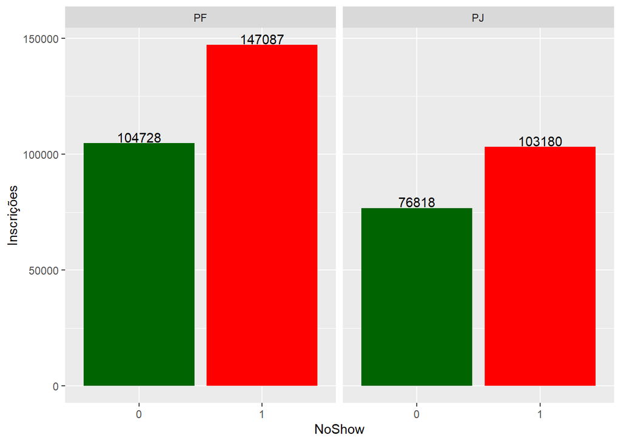

## 3.3 Variável Sexo

A quantidade de inscrições de mulheres é bem maior que a de homens, mas ambas possuem **NoShow** semelhante. Portanto, podemos inferir visualmente que, não há muita relação entre homem e mulher na hora do cliente apresentar **NoShow**. O que não impede esta variável de fazer parte do modelo preditivo final.

- Mulher - **58,79%**
- Homem - **56,23%**

O banco contém **290.893** de inscrições de mulheres e **140.920** de inscrições de homens.

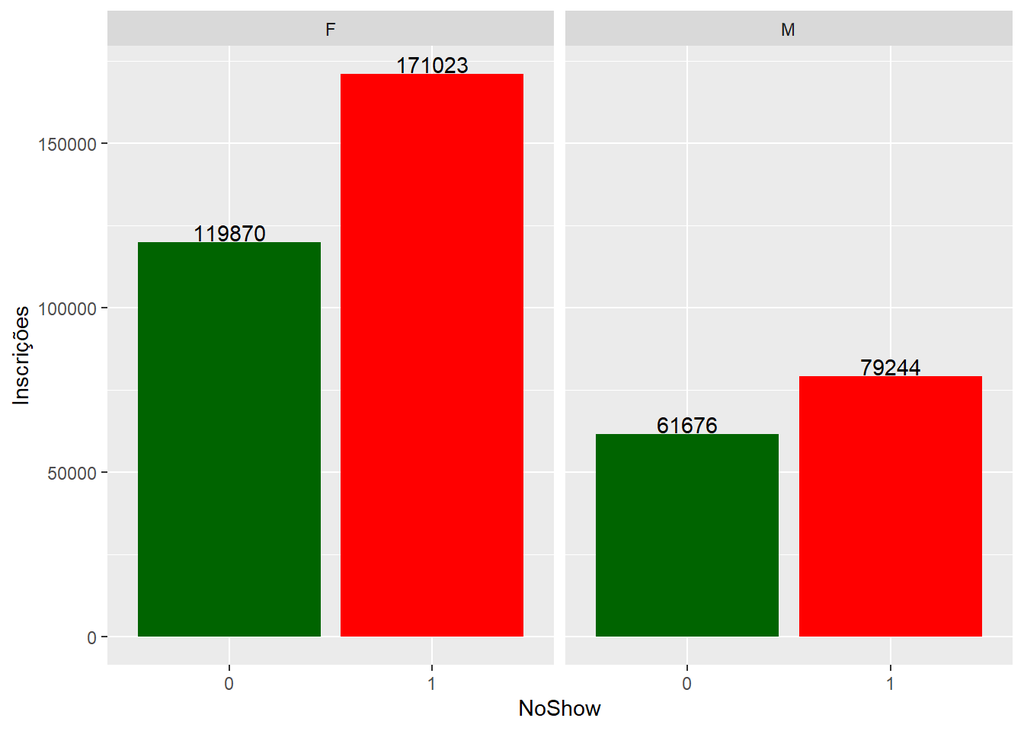

## 3.4 Variável Canal_Inscrição

Esta variável indica por qual meio o cliente fez a sua inscrição. Os dados nos mostram que os canais presenciais ER e Sebrae Aqui tem o melhor desempenho, com **NoShow** por volta de **50%**.

- Canais Digitais
  - Atendimento Remoto - **65,71%**
  - Telemarketing Ativo - **71,71%**
  - Portal - **68,98%**
  - Soluções Digitais - **91,81%**
- Canais Presenciais
  - ER - **50,24%**
  - Sebrae Aqui - **51,12%**
- Híbridos
  - Sede - **65,78%**

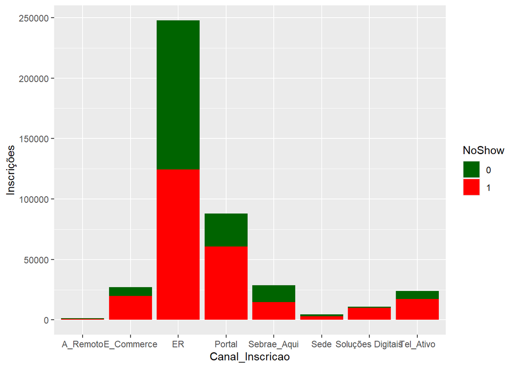

## 3.5 Variável Período

Aqui vemos em qual período do dia a turma está iniciando. Os horários foram divididos em 6 grupos, os quais representam as seguintes faixas de horário:

*M1 - até 08:30AM

*M2 - até 11:30AM

*T1 - até 03:30PM

*T2 - até 06:30PM

*N1 - até 08:30PM

*N2 - até 11:59PM

- Manhã
  - 1 - **45,98%**
  - 2 - **63,98%**
- Tarde
  - 1 - **64,90%**
  - 2 - **65,14%**
- Noite
  - 1 - **53,24%**
  - 2 - **45,98%**

Podemos observar que o N1 tem um resultado muito bom. Ou seja, começar as turmas entre 6:30Pm e 8:30PM é uma boa! M1 e N2 também tem bons resultados, mas por ter um volume baixo de turmas, não podemos concluir muita coisa.

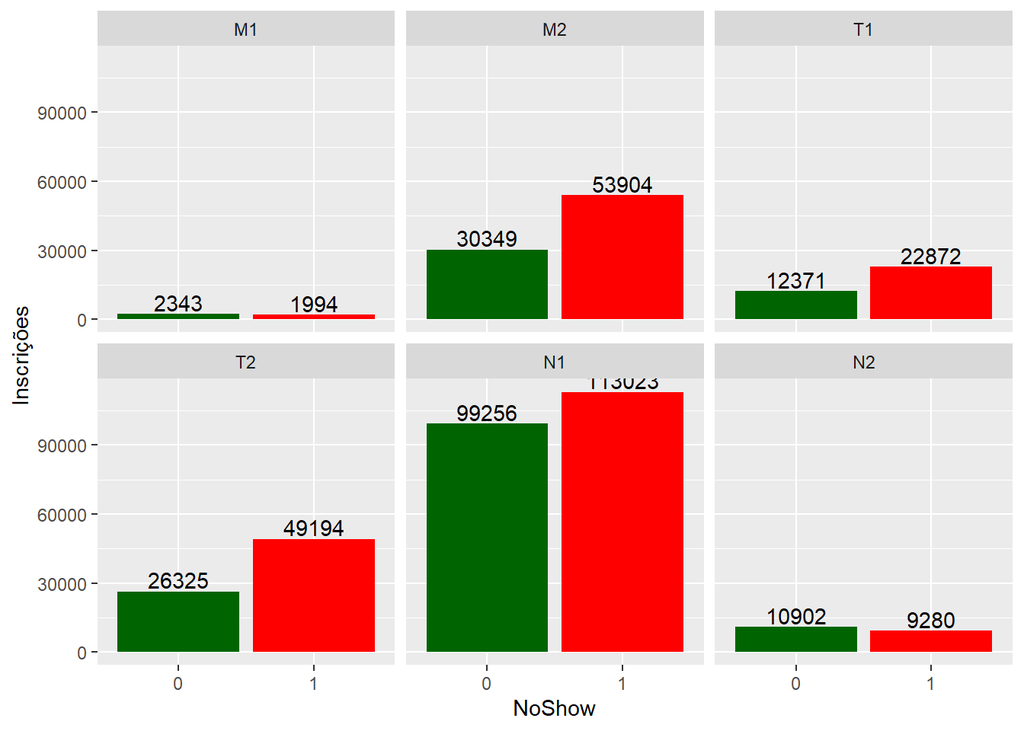

## 3.6 Variável DiaSemana

Aqui analisamos os dias da semana, como boa parte da nossa execução é pautada em kits ou produtos de 5 dias, a distribuição entre os dias da semana é bem uniforme, mesmo assim algumas inferências podem ser feitas.

- Semana
  - segunda - **55,61%**
  - Terça - **56,71%**
  - Quarta - **57,74%**
  - Quinta - **58,78%**
  - Sexta - **62,33%**
- FDS
  - Sábado - **51,42%**
  - Domingo - **84,49%**

Podemos observar que durante a semana, sexta-feira não é um dia muito bom para aplicar coletivos. Já nos finais de semana, mesmo com um volume baixo de turmas, o domingo não é nada recomendado.

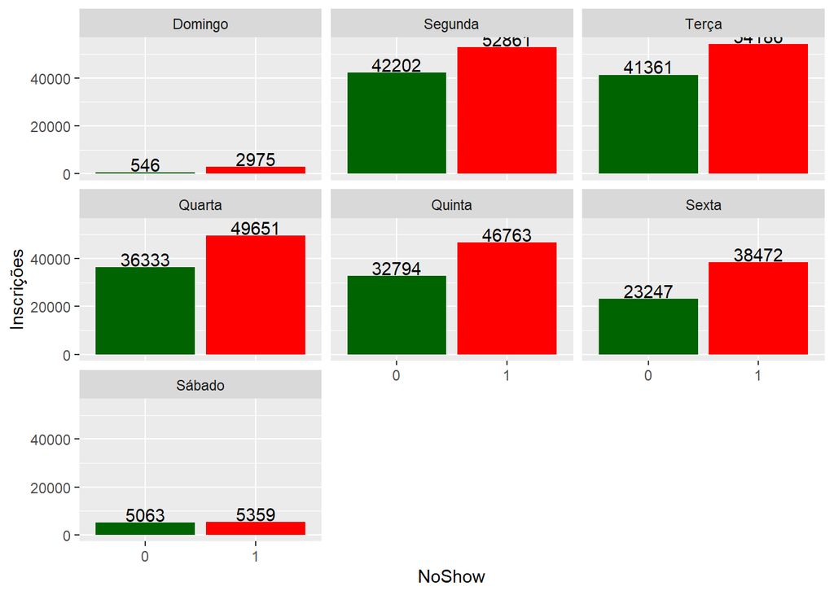

## 3.7 Variável TurmaRestrita

Turmas restritas são turmas em que a Unidade Responsável fecha para um grupo específico de clientes, não sendo possível a inscrição via canais digitais e remotos.

Há uma boa diferença entre o **NoShow** nesse caso, visto que a turma fechada recebe um engajamento maior por parte do cliente.

- Turmas Restritas (1) - **53,74%**
- Turmas Abertas (0) - **63,30%**

Isto mostra a importância de fechar parcerias e tentar vender projetos conectados nos municípios.

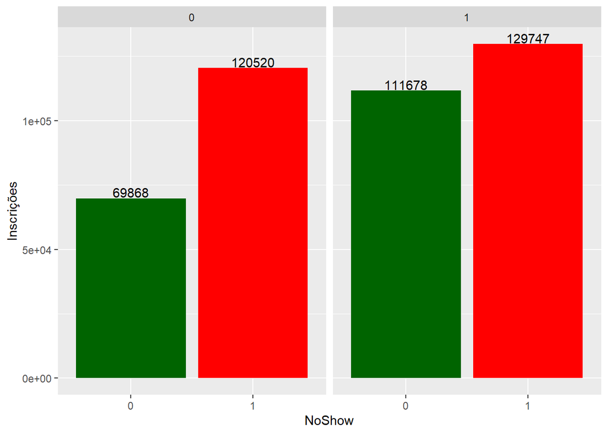

## 3.8 Variável Dif

Esta variável é a diferença de dias entre o dia da inscrição e o dia de início da turma. Podemos observar no gráfico abaixo que quanto mais próximo do início da turma, menor é o **NoShow**. Isto indica que o cliente perde um pouco do engajamento quando sua inscrição é feita com vários dias de antecedência.

Quando a inscrição é feita horas antes do início da turma, o **NoShow** fica por volta de **44%**, com 1 dias antes **48,87%**, já com 9 dias, o resultado fica em **60%**.

Logo, é interessante se atentar para esses clientes que foram inscritos a mais tempo e tentar mantê-los engajados.

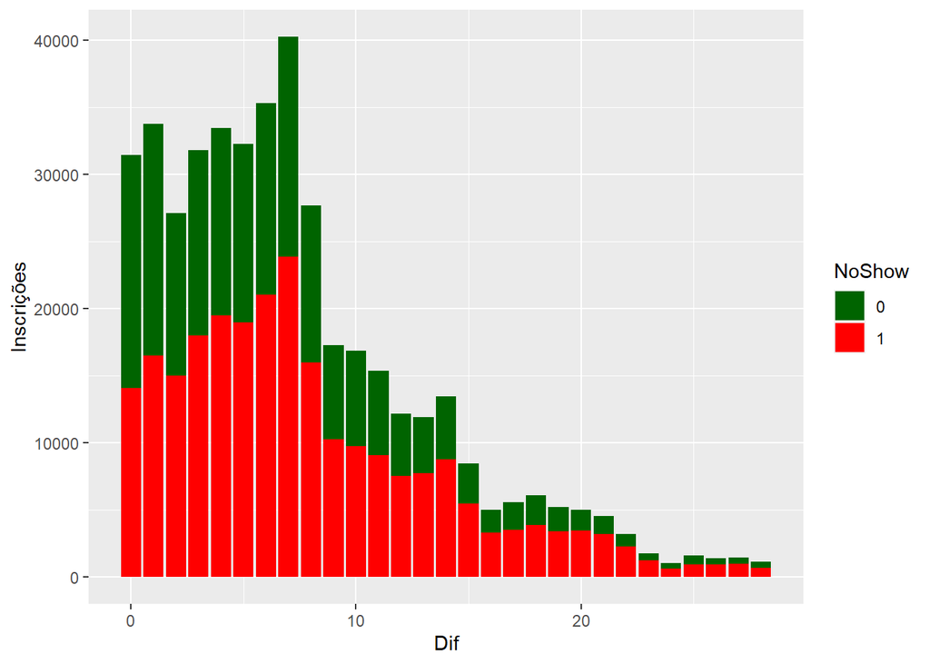

## 3.9 Variável Idade

A idade do cliente não demonstra ter muita influência no **NoShow**, porém ela ainda pode fazer parte do modelo preditivo final se houver significância estatística para ela.

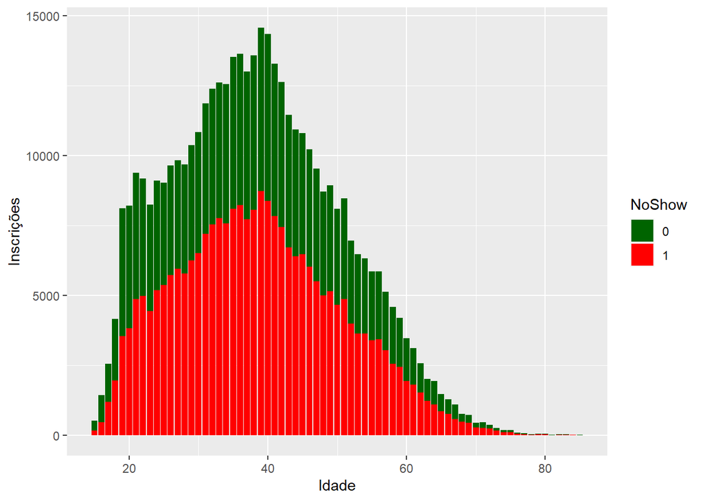

## 3.10 Variável Família

Aqui observamos que soluções de terceiros possuem um **NoShow** menor (**43,87%** contra **58,55%**). Isto tem mais relação com a quantidade de oferta dos produtos (observar grande discrepância no gráfico). Produtos com alta oferta não geram sensação de escassez.

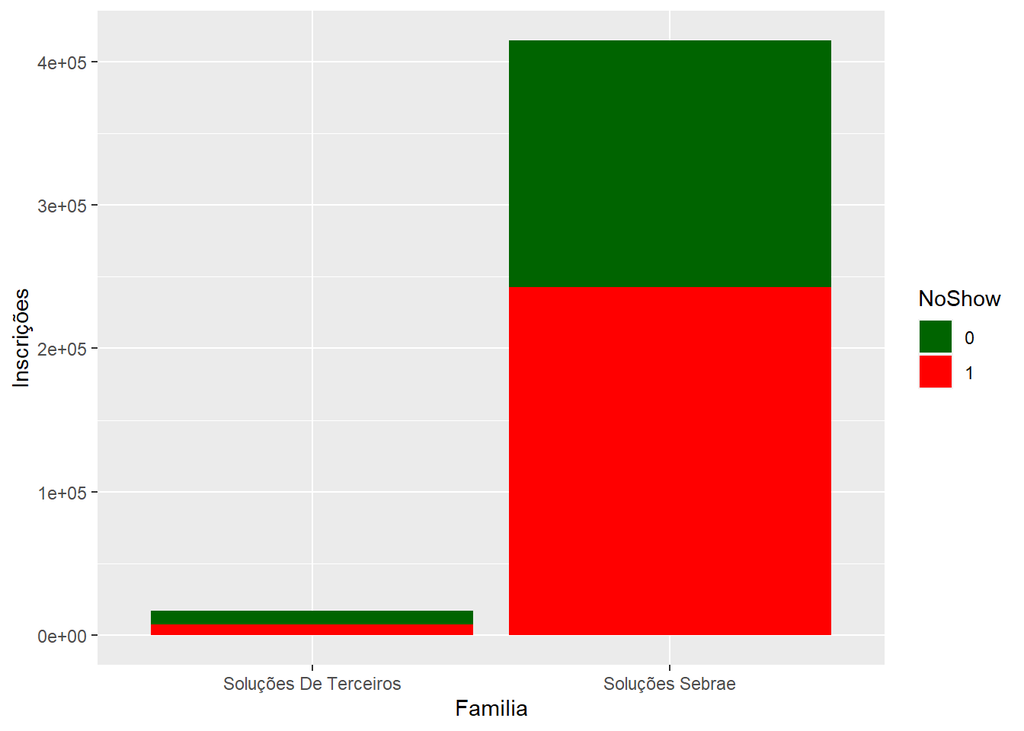

## 3.11 Variável CargaHor

A carga horária do coletivo é exibida em minutos aqui. Aproximadamente **92%** dos produtos analisados aqui tem 2h de duração. Os valores de **NoShow** para cada carga horaria seguem abaixo:

- 60 - **54,04%**
- 120 - **58,79%**
- 180 - **32,73%**
- 240 - **43,59%**
- 480 - **35,46%**
- 600 - **46,31%**
- 900 - **18,68%**
- 960 - **48,21%**
- 1200 - **38,79%**
- 2400 - **44,19%**

Aqui temos que ter cuidado ao analisar esses resultados, visto que o volume de apenas um item é muito superior aos outros. O que podemos inferir é que produtos de maior carga horária são vistos com mais valor pelo cliente. Mas podemos esbarrar na análise anterior de oferta e escassez.

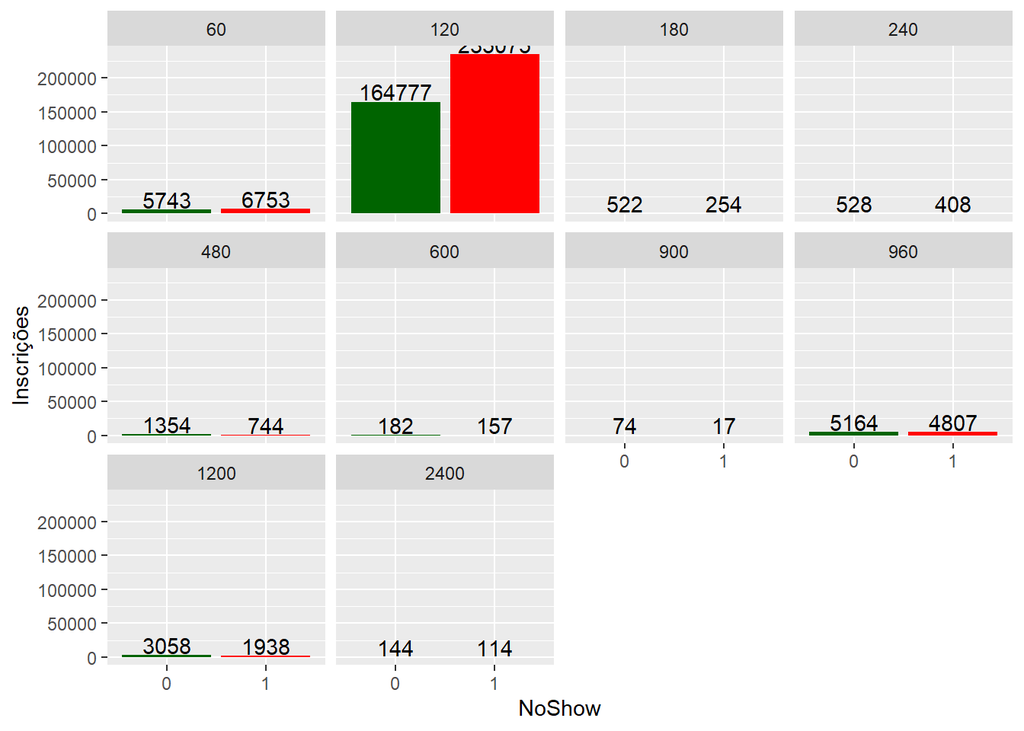

## 3.12 Variável Instrumento

Com os instrumentos, temos um resultado parecido com a carga horária, o que mais abaixo neste trabalho detectaremos colinearidade entre essas variáveis. Ou seja, não precisamos das 2 para colocar no modelo preditivo.

- Cursos - **43,95%**
- Oficinas - **58,85%**
- Palestras - **55,90%**

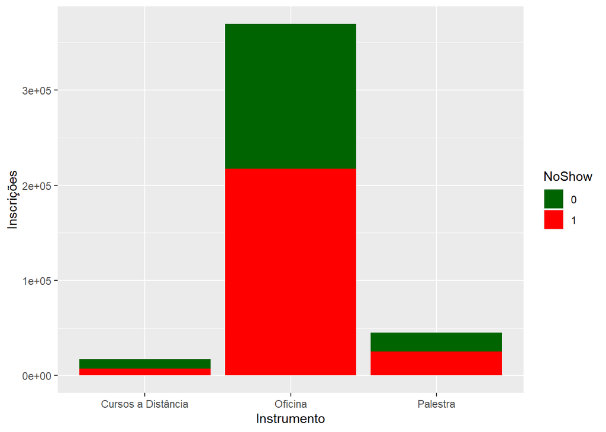

## 3.13 Variável Score

Por fim, nossa variável Score traz o retrospecto do cliente no Sebrae. Ela é uma razão de presenças sobre a quantidade de inscrições que o cliente fez no período de 2020 e primeiro trimestre de 2021. Para clientes novos, esta variável recebe o valor 0. E para os clientes que se inscrevem, mas não possuem nenhuma presença, estes recebem uma penalidade igual a 1/10 da quantidade de inscrições realizadas.

Para Presenças > 0 e Inscrições > 0:

$Score = \frac{Presenças}{Inscrições}$

Para Presenças = 0 e Inscrições > 0:

$Score = Inscrições * (\frac{-1}{10})$

Para Presenças = 0 e Inscrições = 0:

$Score = 0$

Abaixo vemos apenas a distribuição do Score nesta base. A maior parte dos clientes são novos e estão no valor 0.

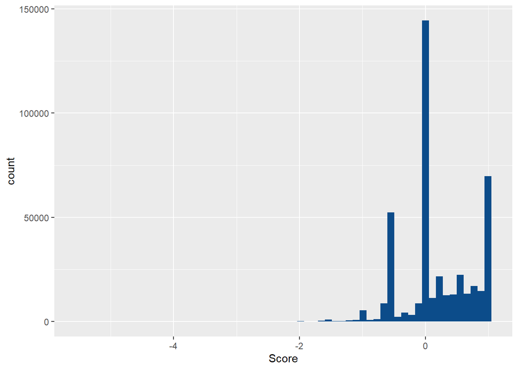

# 4 Checando Colinearidade

Quando trabalhamos com mais de uma variável regressora, é muito importante verificar se essas variáveis explicativas são correlacionadas. Se as variáveis forem muito correlacionadas, as inferências baseadas no modelo de regressão podem ser errôneas ou pouco confiáveis. Na matriz de correlação abaixo, podemos notar a existência de colinearidade entre as variáveis **Instrumento**, **família** e **Carga Horária**, o que é lógico visto que são todas relaciodas ao produto. Neste caso, para o modelo de regressão, vamos remover 2 delas, pois não são necessárias.

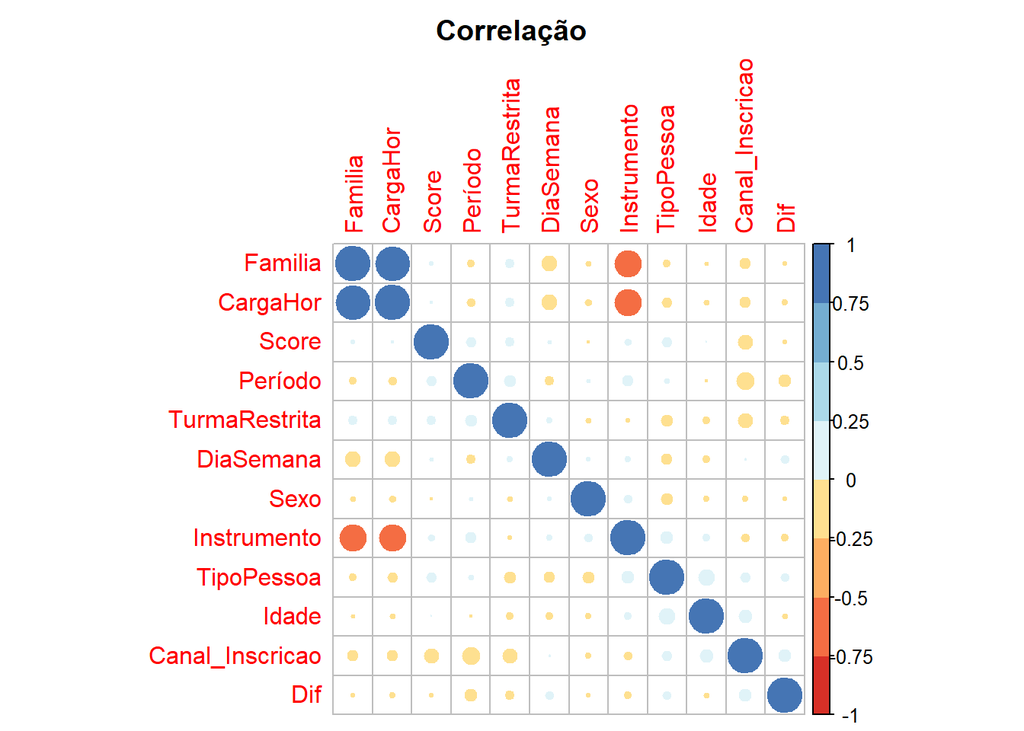

# 5 Regressão Logística

```r
# removendo as colunas do banco de dados que não participam do modelo de previsão
DF <- base[,-c(1,10,11,13)]
# criando as bases de aprendizado e teste
set.seed(91)
index=sample(1:431813, 300000)
lrn = DF[index,]
tst = DF[-index,]
# rodando o algoritomo para geração do modelo
mod1=glm(data = lrn, NoShow~.,family = binomial(link = 'logit') )
# melhorando o modelo
mod2=step(mod1, direction = 'both')
```

```
## Start:  AIC=315779.7
## NoShow ~ TipoPessoa + Sexo + Canal_Inscricao + Período + DiaSemana +
##     TurmaRestrita + Dif + Idade + CargaHor + Score
##
##                   Df Deviance    AIC
## <none>                 315728 315780
## - TipoPessoa       1   315769 315819
## - Idade            1   315858 315908
## - TurmaRestrita    1   316020 316070
## - Sexo             1   316052 316102
## - CargaHor         1   316176 316226
## - DiaSemana        6   316315 316355
## - Período          5   316316 316358
## - Dif              1   317125 317175
## - Canal_Inscricao  7   318990 319028
## - Score            1   388267 388317
```

```r
# exibindo o resultado
summary(mod2)
```

```
##
## Call:
## glm(formula = NoShow ~ TipoPessoa + Sexo + Canal_Inscricao +
##     Período + DiaSemana + TurmaRestrita + Dif + Idade + CargaHor +
##     Score, family = binomial(link = "logit"), data = lrn)
##
## Deviance Residuals:
##     Min       1Q   Median       3Q      Max
## -4.1082  -0.7925   0.4261   0.8707   2.6203
##
## Coefficients:
##                                    Estimate Std. Error  z value Pr(>|z|)
## (Intercept)                       1.984e+00  1.100e-01   18.026  < 2e-16 ***
## TipoPessoaPJ                      6.119e-02  9.545e-03    6.411 1.45e-10 ***
## SexoM                            -1.691e-01  9.390e-03  -18.007  < 2e-16 ***
## Canal_InscricaoE_Commerce        -1.504e-01  7.938e-02   -1.894 0.058198 .
## Canal_InscricaoER                -7.941e-01  7.700e-02  -10.313  < 2e-16 ***
## Canal_InscricaoPortal            -4.377e-01  7.742e-02   -5.653 1.57e-08 ***
## Canal_InscricaoSebrae_Aqui       -7.705e-01  7.860e-02   -9.803  < 2e-16 ***
## Canal_InscricaoSede              -7.391e-01  8.908e-02   -8.297  < 2e-16 ***
## Canal_InscricaoSoluções Digitais  8.749e-01  8.941e-02    9.785  < 2e-16 ***
## Canal_InscricaoTel_Ativo         -2.734e-01  7.899e-02   -3.461 0.000538 ***
## PeríodoM2                         4.047e-01  4.306e-02    9.397  < 2e-16 ***
## PeríodoN1                         2.493e-01  4.237e-02    5.884 4.01e-09 ***
## PeríodoN2                         1.262e-01  4.647e-02    2.716 0.006617 **
## PeríodoT1                         4.931e-01  4.451e-02   11.079  < 2e-16 ***
## PeríodoT2                         4.694e-01  4.321e-02   10.864  < 2e-16 ***
## DiaSemanaQuarta                  -9.673e-01  6.457e-02  -14.981  < 2e-16 ***
## DiaSemanaQuinta                  -9.731e-01  6.463e-02  -15.057  < 2e-16 ***
## DiaSemanaSábado                  -1.061e+00  6.991e-02  -15.172  < 2e-16 ***
## DiaSemanaSegunda                 -1.081e+00  6.459e-02  -16.742  < 2e-16 ***
## DiaSemanaSexta                   -8.490e-01  6.495e-02  -13.072  < 2e-16 ***
## DiaSemanaTerça                   -1.067e+00  6.451e-02  -16.545  < 2e-16 ***
## TurmaRestrita                    -1.597e-01  9.354e-03  -17.075  < 2e-16 ***
## Dif                               2.955e-02  7.958e-04   37.132  < 2e-16 ***
## Idade                             4.277e-03  3.753e-04   11.396  < 2e-16 ***
## CargaHor                         -5.095e-04  2.415e-05  -21.100  < 2e-16 ***
## Score                            -2.298e+00  9.925e-03 -231.583  < 2e-16 ***
## ---
## Signif. codes:  0 '***' 0.001 '**' 0.01 '*' 0.05 '.' 0.1 ' ' 1
##
## (Dispersion parameter for binomial family taken to be 1)
##
##     Null deviance: 408263  on 299999  degrees of freedom
## Residual deviance: 315728  on 299974  degrees of freedom
## AIC: 315780
##
## Number of Fisher Scoring iterations: 5
```

```r
# aplicando o modelo na base de testes
tst$ps=predict(mod2, newdata = tst, type = "response")
```

# 6 Checando Multicolinearidade no Modelo

Aqui precisamos checar se no modelo criado ainda existe a multicolinearidade, mesmo tendo feito a matriz de correlação acima. Os resutlados de todas as variáveis devem ser menores que 5. Aqui todas está OK.

```r
round(vif(mod2b),1)
```

```
##      TipoPessoa            Sexo Canal_Inscricao         Período       DiaSemana
##             1.1             1.0             1.1             1.1             1.1
##   TurmaRestrita             Dif           Idade        CargaHor           Score
##             1.1             1.0             1.1             1.1             1.0
```

# 7 Validação

## 7.1 Matriz de Classificação

Agora vamos testar o modelo. Ele foi criado utilizando uma fração da base de dados (lrn - base de aprendizado) e agora vai ser testado na outra fração da base de dados (tst - base de teste).

0 e 1 são os resultados reais, noshow_nao e noshow_sim são as predições feitas pelo modelo.

Logo, acertamos 31.680 casos de noshow_nao e 63.019 casos de noshow_sim. Somando esse 2 e dividindo pelo total desta base de teste, chegamos na acurácia do modelo, que é de **71,84%**.

```r
PC=0.5
klas=ifelse(tst$ps>=PC,"noshow_sim","noshow_nao")
table(tst$NoShow,klas)
```

```
##    klas
##     noshow_nao noshow_sim
##   0      31680      23729
##   1      13385      63019
```

```r
(31680+63019)/131813 #71,84%
```

```
## [1] 0.7184344
```

## 7.2 Comparação Visual das Pobabilidades Estimadas

Se analisarmos em quebras de intervalos, podemos ser mais precisos na predição que fazemos sobre o cliente faltar ou não. Na matriz abaixo, observamos que nos intevalos das extremidades, a precisão do modelo é bem alta, sendo **84,5%** de acerto quando a predição for menor que **26,9%**. E **94,2%** quando a predição for maior que **83,7%**.

```r
ProbEstimada=discretize(tst$ps, method = 'frequency', breaks = 5)
m=table(ProbEstimada, tst$NoShow)
mp=prop.table(m,1)
print(mp,digits=2)
```

```
##
## ProbEstimada         0     1
##   [0.0314,0.269) 0.845 0.155
##   [0.269,0.571)  0.469 0.531
##   [0.571,0.687)  0.432 0.568
##   [0.687,0.837)  0.298 0.702
##   [0.837,1]      0.058 0.942
```

# 8 Conclusão e Aplicação

E na prática como tiramos proveito destá análise. Em primeiro lugar é interessante ter mais atenção nas variáveis relacionadas a disponibilização da turma, para que o risco de **NoShow** seja minimizado.

Em segundo lugar, estamos disponibilzando um relatório no BI com este modelo preditivo aplicado as turmas futuras. O relatório do link [Link](https://relatorios.sebraesp.com.br/Reports/powerbi/Unidades/UAC/2021/Turmas) traz a informação da probabilidade dos clientes apresentarem **NoShow**.

o que fazer com o relatório?

- Ligar para os clientes com maior probabilidade de **NoShow** antes das turmas acontecerem, tentando minimizar esse risco
- Prever quantos clientes estarão presentes na turma
- Traçar ações para melhorar esses resultados
- Inscrever os clientes com uma janela de antecedência menor possível

E o mais importante de tudo, tentar respeitar os processos ao máximo, para que análises como esta sejam possíveis.

- Não fazer listas paralelas de inscrições
- Abrir as turmas com antecedência
- Inscrever os clientes antes do início da turma
- Prestar atenção nos planos orçamentários corretos para não precisar reabrir a turma
- Atualizar os cadastros dos clientes sempre que possível

Qualquer dúvida ou sugestão falar com a equipe da UAC

- danielrmb@sebraesp.com.br
- adrianogc@sebraesp.com.br
- brunoms@sebraesp.com.br
- marceloasf@sebraesp.com.br
- viniciusns@sebraesp.com.br
- e_viniciusb@sebraesp.com.br
- silasmc@sebraesp.com.br